# DƏRS 3: Rubrik Əsaslı Qiymətləndirmə Sistemi

Müasir rubrik metodologiyaları və onların praktiki tətbiqi

Azərbaycan Respublikası Təhsil Nazirliyi - Peşəkar İnkişaf Mərkəzi

2025-08-01

### 🎯 DƏRSİN ÖYRƏNMƏ MƏQSƏDLƏRİ

Bu dərsin sonunda siz aşağıdakıları bacara biləcəksiniz:

- **Rubrik dizaynı:** Müasir rubrik prinsiplərinə əsaslanan effektiv qiymətləndirmə alətləri yaratmaq
- **Analitik rubrik:** Hər kriteriya üçün detallı qiymətləndirmə səviyyələri hazırlamaq
- **Holistik rubrik:** Ümumi performans qiymətləndirməsi metodlarını tətbiq etmək
- **Əks əlaqə strategiyaları:** Konstruktiv və inkişaf yönümlü geri bildirim vermə texnikaları
- **Texnoloji dəstək:** Rəqəmsal alətlərlə rubrik tətbiqini effektivləşdirmək
- **Keyfiyyət nəzarəti:** Rubrik etibarlılığını və validliyini təmin etmə metodları

# 1 Rubrik Qiymətləndirmə Sisteminin Əsasları

Rubrik əsaslı qiymətləndirmə müasir təhsildə ən effektiv və şəffaf qiymətləndirmə metodlarından biridir. Bu sistem həm müəllimlərə, həm də tələbələrə aydın performans gözləntiləri və kriterilar təqdim edir.

```r
# Rubrik qiymətləndirmə sisteminin əsas komponentləri
rubric_components <- tibble(
  Component = c("Performans Kriteriyaları", "Qiymətləndirmə Səviyyələri", "Deskriptor Cədvəli",
                "Bal Skalası", "Keyfiyyət İndikatorları", "Əks Əlaqə Strukturu"),
  Definition = c("Qiymətləndirilən əsas sahələr və aspektlər",
                "Hər kriteriya üçün müxtəlif performans dərəcələri",
                "Hər səviyyə üçün ətraflı təsvir və gözlənti",
                "Rəqəmsal və ya hərf sistemi ilə bal təyin edilməsi",
                "Keyfiyyətli işin əlamətləri və nümunələri",
                "Tələbəyə verilən sistemli geri bildirim formatı"),
  Importance = c(95, 90, 88, 85, 92, 94),
  Implementation_Difficulty = c(60, 50, 70, 40, 65, 75)
)

kable(rubric_components,
      caption = "Rubrik Qiymətləndirmə Sisteminin Əsas Komponentləri",
      col.names = c("Komponent", "Tərift", "Əhəmiyyət (%)", "Tətbiq Çətinliyi (%)")) %>%
  kable_styling(bootstrap_options = c("striped", "hover", "condensed", "responsive")) %>%
  column_spec(1, bold = TRUE, color = "white", background = "#667eea") %>%
  column_spec(3, bold = TRUE, color = "#27ae60") %>%
  column_spec(4, bold = TRUE, color = "#e74c3c")
```

Rubrik Qiymətləndirmə Sisteminin Əsas Komponentləri

| Komponent | Tərift | Əhəmiyyət (%) | Tətbiq Çətinliyi (%) |
| --- | --- | --- | --- |
| Performans Kriteriyaları | Qiymətləndirilən əsas sahələr və aspektlər | 95 | 60 |
| Qiymətləndirmə Səviyyələri | Hər kriteriya üçün müxtəlif performans dərəcələri | 90 | 50 |
| Deskriptor Cədvəli | Hər səviyyə üçün ətraflı təsvir və gözlənti | 88 | 70 |
| Bal Skalası | Rəqəmsal və ya hərf sistemi ilə bal təyin edilməsi | 85 | 40 |
| Keyfiyyət İndikatorları | Keyfiyyətli işin əlamətləri və nümunələri | 92 | 65 |
| Əks Əlaqə Strukturu | Tələbəyə verilən sistemli geri bildirim formatı | 94 | 75 |

```r
cat("📊 RUBRİK SİSTEMİ TƏHLİLİ:\n")
```

```
#> 📊 RUBRİK SİSTEMİ TƏHLİLİ:
```

```r
cat("=======================\n")
cat("🎯 Ümumi komponent sayı:", nrow(rubric_components), "\n")
```

```
#> 🎯 Ümumi komponent sayı: 6
```

```r
cat("📈 Orta əhəmiyyət dərəcəsi:", round(mean(rubric_components$Importance), 1), "%\n")
```

```
#> 📈 Orta əhəmiyyət dərəcəsi: 90.7 %
```

```r
cat("⚡ Orta tətbiq çətinliyi:", round(mean(rubric_components$Implementation_Difficulty), 1), "%\n")
```

```
#> ⚡ Orta tətbiq çətinliyi: 60 %
```

```r
cat("🏆 Ən vacib komponent:", rubric_components$Component[which.max(rubric_components$Importance)], "\n")
```

```
#> 🏆 Ən vacib komponent: Performans Kriteriyaları
```

#### 🏗️ Rubrik Dizayn Prinsipləri

**Aydınlıq və Anlaşıqlılıq:**

- Hər kriteriya və səviyyə dəqiq, anlaşılan dildə yazılmalıdır
- Müəyyənliksizlik və ikilikə yol verilməməlidir
- Tələbələr rubrikdən istifadə edərək öz işlərini qiymətləndirə bilməlidir

**Ədalətlilik və Obyektivlik:**

- Bütün tələbələr üçün eyni kriteriyalar tətbiq edilməlidir
- Şəxsi üstünlüklər və qərəzlər minimum səviyyədə olmalıdır
- Etibarlı və davamlı qiymətləndirmə təmin edilməlidir

# 2 Analitik Rubrik Metodologiyası

Analitik rubrik hər performans kriteriyasını ayrıca qiymətləndirən detallı sistem metodudur. Bu metodda hər sahə üçün müstəqil bal verilir və sonra ümumi nəticə hesablanır.

```r
# Analitik rubrik strukturunun nümunəsi
analytical_rubric <- tibble(
  Criteria = rep(c("Məzmun və İdeyalar", "Təşkilat", "Dil və Üslub", "Qrammatika"), each = 4),
  Level = rep(c("Əla (4)", "Yaxşı (3)", "Orta (2)", "Zəif (1)"), 4),
  Score_Range = rep(c("91-100", "81-90", "71-80", "60-70"), 4),
  Description = c(
    # Məzmun və İdeyalar
    "Orijinal, yaradıcı və dərin fikirlər, mövzunun hərtərəfli araşdırılması",
    "Mövzuya uyğun və əsaslı fikirlər, yaxşı inkişaf etdirilmiş ideyalar",
    "Əsas mövzunu əhatə edir, lakin bəzi sahələr səthidir",
    "Mövzudan kənarlaşmalar, zəif inkişaf etdirilmiş ideyalar",
    # Təşkilat
    "Mükəmməl struktur, effektiv keçidlər, məntiqi ardıcıllıq",
    "Aydın struktur, əksər keçidlər düzgündür",
    "Əsas struktur mövcuddur, bəzi təşkilat problemləri",
    "Qarışıq struktur, zəif təşkilat və keçidlər",
    # Dil və Üslub
    "Zəngin lüğət, müxtəlif cümlə strukturları, təsiredici üslub",
    "Uyğun lüğət seçimi, yaxşı cümlə quruluşu",
    "Sadə amma düzgün dil, məhdud lüğət",
    "Çox sadə dil, təkrarlanan strukturlar",
    # Qrammatika
    "Demək olar ki, səhvsiz, yüksək dil keyfiyyəti",
    "Kiçik səhvlər anlamaya mane olmur",
    "Bəzi qrammatik səhvlər, lakin oxunaqlıdır",
    "Çoxsaylı səhvlər anlamanı çətinləşdirir"
  )
)

# Kriteriya üzrə səviyyələrin cədvəli
kable(analytical_rubric %>%
        select(Criteria, Level, Score_Range, Description) %>%
        filter(str_detect(Level, "Əla|Zəif")),
      caption = "Analitik Rubrik Nümunəsi: Yüksək və Aşağı Səviyyələr",
      col.names = c("Kriteriya", "Səviyyə", "Bal Aralığı", "Təsvir")) %>%
  kable_styling(bootstrap_options = c("striped", "hover", "condensed", "responsive")) %>%
  column_spec(1, bold = TRUE, color = "white", background = "#667eea") %>%
  column_spec(2, bold = TRUE) %>%
  row_spec(which(str_detect(analytical_rubric$Level[analytical_rubric$Level %in% c("Əla (4)", "Zəif (1)")], "Əla")),
           background = "#d4edda") %>%
  row_spec(which(str_detect(analytical_rubric$Level[analytical_rubric$Level %in% c("Əla (4)", "Zəif (1)")], "Zəif")),
           background = "#f8d7da")
```

Analitik Rubrik Nümunəsi: Yüksək və Aşağı Səviyyələr

| Kriteriya | Səviyyə | Bal Aralığı | Təsvir |
| --- | --- | --- | --- |
| Məzmun və İdeyalar | Əla (4) | 91-100 | Orijinal, yaradıcı və dərin fikirlər, mövzunun hərtərəfli araşdırılması |
| Məzmun və İdeyalar | Zəif (1) | 60-70 | Mövzudan kənarlaşmalar, zəif inkişaf etdirilmiş ideyalar |
| Təşkilat | Əla (4) | 91-100 | Mükəmməl struktur, effektiv keçidlər, məntiqi ardıcıllıq |
| Təşkilat | Zəif (1) | 60-70 | Qarışıq struktur, zəif təşkilat və keçidlər |
| Dil və Üslub | Əla (4) | 91-100 | Zəngin lüğət, müxtəlif cümlə strukturları, təsiredici üslub |
| Dil və Üslub | Zəif (1) | 60-70 | Çox sadə dil, təkrarlanan strukturlar |
| Qrammatika | Əla (4) | 91-100 | Demək olar ki, səhvsiz, yüksək dil keyfiyyəti |
| Qrammatika | Zəif (1) | 60-70 | Çoxsaylı səhvlər anlamanı çətinləşdirir |

```r
# Kriteriyalar arası korrelyasiya təhlili
set.seed(123)
sample_scores <- tibble(
  Student_ID = 1:50,
  Content = rnorm(50, 80, 10),
  Organization = rnorm(50, 78, 8),
  Language = rnorm(50, 76, 12),
  Grammar = rnorm(50, 82, 9)
) %>%
  mutate(across(Content:Grammar, ~pmax(pmin(round(.x), 100), 60)))

correlation_matrix <- cor(sample_scores[, 2:5])

cat("\n📊 KRİTERİYALAR ARASI KORRELYASIYA:\n")
```

```
#>
#> 📊 KRİTERİYALAR ARASI KORRELYASIYA:
```

```r
cat("===============================\n")
for(i in 1:nrow(correlation_matrix)) {
  for(j in 1:ncol(correlation_matrix)) {
    if(i < j) {
      cat(sprintf("🔗 %s - %s: %.3f\n",
                  colnames(correlation_matrix)[i],
                  colnames(correlation_matrix)[j],
                  correlation_matrix[i,j]))
    }
  }
}
```

```
#> 🔗 Content - Organization: -0.030
#> 🔗 Content - Language: 0.057
#> 🔗 Content - Grammar: -0.133
#> 🔗 Organization - Language: -0.166
#> 🔗 Organization - Grammar: -0.134
#> 🔗 Language - Grammar: -0.047
```

#### 📏 Analitik Rubrik Üstünlükləri

**Detallı Qiymətləndirmə:**

- Hər sahə üçün spesifik geri bildirim imkanı
- Güclü və zəif tərəflərin dəqiq müəyyənləşdirilməsi
- Fərdi inkişaf planının yaradılması

**Tədrisi Dəstək:**

- Müəllim üçün hədəfli təlimat planlaması
- Tələbə tərəqqisinin izlənməsi
- Məzmun sahələrində boşluqların aşkarlanması

# 3 Holistik Rubrik Metodologiyası

Holistik rubrik ümumi performansı vahid bir baxışla qiymətləndirən metoddur. Bu yanaşma işin ümumi keyfiyyətinə diqqət yetirir və ayrı-ayrı komponentləri deyil, bütöv məhsulu qiymətləndirir.

```r
# Holistik rubrik strukturu
holistic_rubrik <- tibble(
  Level = c("Əla (A)", "Yaxşı (B)", "Qənaətbəxş (C)", "Zəif (D/F)"),
  Score_Range = c("90-100", "80-89", "70-79", "60-69"),
  Overall_Description = c(
    "İstisnaili keyfiyyət: Orijinal, yaradıcı və dərin məzmun. Mükəmməl təşkilat və struktur. Zəngin dil və səhvsiz qrammatika. Oxucu üçün cəlbedici və təsiredici təqdimat.",
    "Yüksək keyfiyyət: Mövzunu yaxşı əhatə edən məzmun. Aydın struktur və məntiqi ardıcıllıq. Uyğun dil istifadəsi və az sayda kiçik səhv. Oxunaqlı və anlaşılan təqdimat.",
    "Qənaətbəxş keyfiyyət: Əsas tələbləri ödəyən məzmun. Ümumi struktur aydındır, bəzi təşkilat problemləri. Sadə amma düzgün dil. Bəzi qrammatik səhvlər mövcuddur.",
    "Aşağı keyfiyyət: Zəif və ya natamam məzmun. Qarışıq struktur və təşkilat. Məhdud dil imkanları. Çoxsaylı qrammatik səhvlər anlamanı çətinləşdirir."
  ),
  Key_Indicators = c(
    "Yaradıcılıq, dərinlik, mükəmməllik",
    "Adekvatlıq, aydınlıq, düzgünlük",
    "Əsas tələblər, orta keyfiyyət",
    "Nöqsanlar, çatışmazlıqlar"
  )
)

kable(holistic_rubrik,
      caption = "Holistik Rubrik Nümunəsi: Ümumi Performans Qiymətləndirməsi",
      col.names = c("Səviyyə", "Bal Aralığı", "Ümumi Təsvir", "Açar Göstəricilər")) %>%
  kable_styling(bootstrap_options = c("striped", "hover", "condensed", "responsive")) %>%
  column_spec(1, bold = TRUE, color = "white", background = "#667eea") %>%
  column_spec(2, bold = TRUE, color = "#27ae60") %>%
  row_spec(1, background = "#d4edda") %>%
  row_spec(4, background = "#f8d7da")
```

Holistik Rubrik Nümunəsi: Ümumi Performans Qiymətləndirməsi

| Səviyyə | Bal Aralığı | Ümumi Təsvir | Açar Göstəricilər |
| --- | --- | --- | --- |
| Əla (A) | 90-100 | İstisnaili keyfiyyət: Orijinal, yaradıcı və dərin məzmun. Mükəmməl təşkilat və struktur. Zəngin dil və səhvsiz qrammatika. Oxucu üçün cəlbedici və təsiredici təqdimat. | Yaradıcılıq, dərinlik, mükəmməllik |
| Yaxşı (B) | 80-89 | Yüksək keyfiyyət: Mövzunu yaxşı əhatə edən məzmun. Aydın struktur və məntiqi ardıcıllıq. Uyğun dil istifadəsi və az sayda kiçik səhv. Oxunaqlı və anlaşılan təqdimat. | Adekvatlıq, aydınlıq, düzgünlük |
| Qənaətbəxş (C) | 70-79 | Qənaətbəxş keyfiyyət: Əsas tələbləri ödəyən məzmun. Ümumi struktur aydındır, bəzi təşkilat problemləri. Sadə amma düzgün dil. Bəzi qrammatik səhvlər mövcuddur. | Əsas tələblər, orta keyfiyyət |
| Zəif (D/F) | 60-69 | Aşağı keyfiyyət: Zəif və ya natamam məzmun. Qarışıq struktur və təşkilat. Məhdud dil imkanları. Çoxsaylı qrammatik səhvlər anlamanı çətinləşdirir. | Nöqsanlar, çatışmazlıqlar |

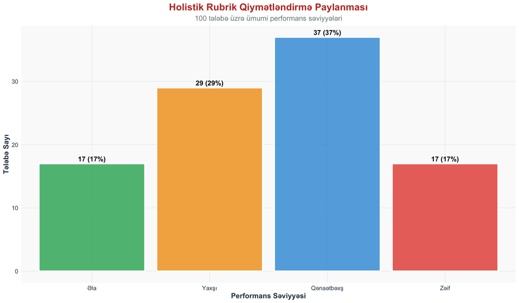

```r
# Holistik qiymətləndirmə paylanması
set.seed(456)
holistic_scores <- tibble(
  Student_ID = 1:100,
  Holistic_Score = sample(c("Əla", "Yaxşı", "Qənaətbəxş", "Zəif"),
                         100, replace = TRUE,
                         prob = c(0.15, 0.35, 0.35, 0.15))
) %>%
  mutate(Holistic_Score = factor(Holistic_Score,
                                levels = c("Əla", "Yaxşı", "Qənaətbəxş", "Zəif")))

score_distribution <- holistic_scores %>%
  count(Holistic_Score) %>%
  mutate(Percentage = round(n/sum(n)*100, 1))

# Paylanma qrafiki
distribution_plot <- score_distribution %>%
  ggplot(aes(x = Holistic_Score, y = n, fill = Holistic_Score)) +
  geom_col(alpha = 0.8, color = "white", size = 1) +
  geom_text(aes(label = paste0(n, " (", Percentage, "%)")),
            vjust = -0.5, fontface = "bold", size = 4) +
  scale_fill_manual(values = c("Əla" = "#27ae60", "Yaxşı" = "#f39c12",
                              "Qənaətbəxş" = "#3498db", "Zəif" = "#e74c3c")) +
  labs(
    title = "Holistik Rubrik Qiymətləndirmə Paylanması",
    subtitle = "100 tələbə üzrə ümumi performans səviyyələri",
    x = "Performans Səviyyəsi",
    y = "Tələbə Sayı",
    fill = "Səviyyə"
  ) +
  theme_rubric_assessment() +
  theme(legend.position = "none")

print(distribution_plot)
```

```r
cat("📈 HOLİSTİK QİYMƏTLƏNDİRMƏ STATİSTİKALARI:\n")
```

```
#> 📈 HOLİSTİK QİYMƏTLƏNDİRMƏ STATİSTİKALARI:
```

```r
cat("=====================================\n")
cat("👥 Ümumi tələbə sayı:", nrow(holistic_scores), "\n")
```

```
#> 👥 Ümumi tələbə sayı: 100
```

```r
cat("🎯 Yüksək səviyyə (Əla+Yaxşı):",
    sum(score_distribution$n[score_distribution$Holistic_Score %in% c("Əla", "Yaxşı")]), "nəfər\n")
```

```
#> 🎯 Yüksək səviyyə (Əla+Yaxşı): 46 nəfər
```

```r
cat("⚠️ Aşağı səviyyə (Zəif):",
    score_distribution$n[score_distribution$Holistic_Score == "Zəif"], "nəfər\n")
```

```
#> ⚠️ Aşağı səviyyə (Zəif): 17 nəfər
```

#### 🎯 Holistik Rubrik Üstünlükləri

**Sürətli Qiymətləndirmə:**

- Qısa müddətdə çoxlu sayda işin qiymətləndirilməsi
- Ümumi keyfiyyət haqqında tez qərar vermə
- Böyük siniflərdə effektiv istifadə imkanı

**Bütöv Baxış:**

- İşin ümumi təsiri və məzmununa fokus
- Ayrı-ayrı səhvlərin ümumi keyfiyyəti kölgələməməsi
- Yaradıcılıq və orijinallığın qiymətləndirilməsi